# Using gghalves

Frederik Tiedemann

This vignette is intended to showcase the usage of the `gghalves` extension by going through the individual `_half_` `geom`s to explain details of usage and function arguments.

## General Idea

The general idea of `gghalves` stems from [this](https://stackoverflow.com/questions/49003863/how-to-plot-a-hybrid-boxplot-half-boxplot-with-jitter-points-on-the-other-half) StackOverflow question on how to plot a hybrid boxplot. This led to me developing the ggpol extension for `ggplot2`. However, the fact that `ggpol` has become a sort of aggregation for all kinds of `geom`s over time, and seeing that [many things can be cut in half](https://github.com/erocoar/ggpol/issues/4), has ultimately led to this library.

The idea is that many `geom`s that aggregate data, such as `geom_boxplot`, `geom_violin` and `geom_dotplot` are (near) symmetric. Given that the space to display information is limited, we can make better use of it by cutting the `geom`s in half and displaying additional `geom`s that e.g. give information about the sample size.

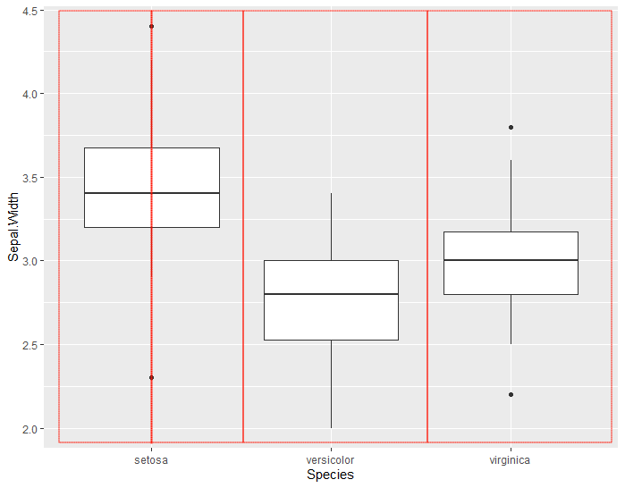

## GeomHalfPoint

`GeomHalfPoint`, perhaps counterintuitively, does not display a literal half-circle. Rather, it plots the data points such that

- the space they occupy is at most half of the space allotted to the specific factor, on the x-axis
- they leave the left or right half of the total space to be used by another `_half_` geom

Further, by default `geom_half_point` **jitters** the points horizontally and vertically.

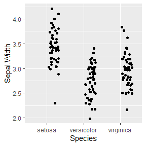

```r
ggplot(iris, aes(x = Species, y = Sepal.Width)) +
  geom_half_point()
```

The way this works is that `transformation = PositionJitter` is passed to the `geom`. We could play with the default values of this transformation by passing along a `transformation_params` argument

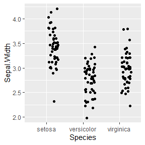

```r
ggplot(iris, aes(x = Species, y = Sepal.Width)) +
  geom_half_point(transformation_params = list(height = 0, width = 0.001, seed = 1))
```

or we could change the `transformation` argument itself:

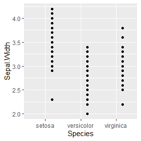

```r
ggplot(iris, aes(x = Species, y = Sepal.Width)) +
  geom_half_point(transformation = PositionIdentity)
```

Making the transformation work with custom `Position`s from `ggplot2` extensions is something that will hopefully be included in future updates of this package.

## GeomHalfPointPanel

Sometimes we want to color points within the `aes()` groupings. In that case, we can make use of `geom_half_point_panel()`.

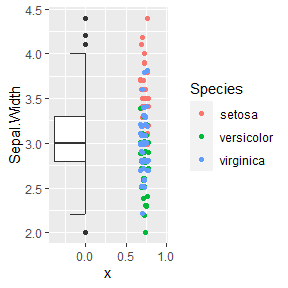

```r
ggplot(iris, aes(y = Sepal.Width)) +
  geom_half_boxplot() +
  geom_half_point_panel(aes(x = 0.5, color = Species), range_scale = .5)
```

Like all `_half_` geoms, `geom_half_point` also takes a `side` argument, with `l` for left and `r` for right.

## GeomHalfBoxplot

`GeomHalfBoxplot` displays a boxplot that is cut in half and plotted either on the left or right side of the space allotted to the specific factor on the x-axis.

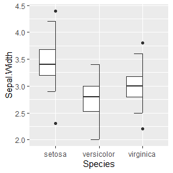

```r
ggplot(iris, aes(x = Species, y = Sepal.Width)) +
  geom_half_boxplot()
```

Additionally to the standard `side` argument, you can also `center` the half-boxplot and decide whether an errorbar is drawn or not.

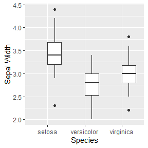

```r
ggplot(iris, aes(x = Species, y = Sepal.Width)) +
  geom_half_boxplot(side = "r", center = TRUE, errorbar.draw = FALSE)
```

## GeomHalfViolin

`GeomHalfViolin` draws a half-violin plot. Besides the `side` argument, it supports all the arguments that can be passed to the standard `GeomViolin`.

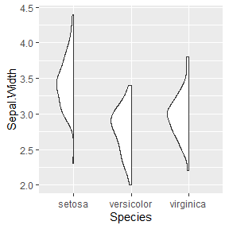

```r
ggplot(iris, aes(x = Species, y = Sepal.Width)) +
  geom_half_violin()
```

Furthermore, if we have a binary grouping variable (such as control/treatment) we can plot side-by-side comparisons with the optional `split` aesthetic:

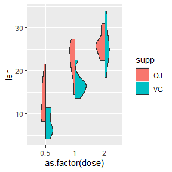

```r
ggplot() +
  geom_half_violin(
    data = ToothGrowth,
    aes(x = as.factor(dose), y = len, split = supp, fill = supp),
    position = "identity"
  )
```

## GeomHalfDotplot

`GeomHalfDotplot` is slightly different from the other `_half_` `geom`s in that it does not support a `side` argument, since this is already inherently built into the standard `GeomDotplot` via `stackdir`:

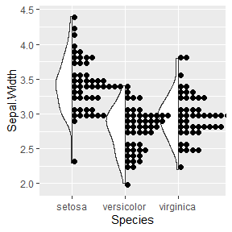

```r
ggplot(iris, aes(x = Species, y = Sepal.Width)) +
  geom_half_violin() +
  geom_dotplot(binaxis = "y", method="histodot", stackdir="up")
```

So, given that `geom_dotplot` can be used as a `_half_` `geom`, why the need for `geom_half_dotplot`? The reason is that `geom_dotplot` does not support dodging when there are multiple factors in play. Let’s consider the following example:

```r
df <- data.frame(score = rgamma(150, 4, 1),
                 gender = sample(c("M", "F"), 150, replace = TRUE),
                genotype = factor(sample(1:3, 150, replace = TRUE)))
```

Given this data, we want to group by `genotype`, but also separate the plots by `gender`. This does not quite work using the standard `geom`:

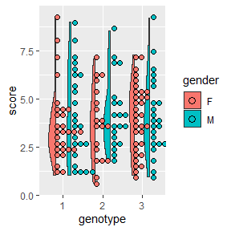

```r
ggplot(df, aes(x = genotype, y = score, fill = gender)) +
  geom_half_violin() +
  geom_dotplot(binaxis = "y", method="histodot", stackdir="up", position = PositionDodge)
```

Using `geom_half_dotplot`, however, we can make this work:

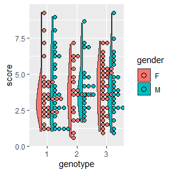

```r
ggplot(df, aes(x = genotype, y = score, fill = gender)) +
  geom_half_violin() +
  geom_half_dotplot(method="histodot", stackdir="up")
```

## Working with ggplot2 Extensions

As mentioned in the package description, `gghalves` can work well in combination with certain `ggplot2` extensions. One of them is `geom_beeswarm` of the `ggbeeswarm` package. Note that, currently, you will need to install the latest version from GitHub to support the passing of `beeswarmArgs`.

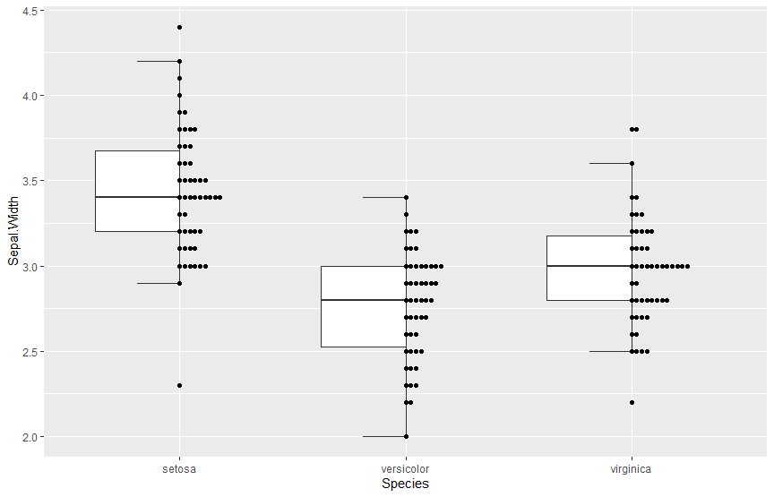

```r
ggplot(iris, aes(x = Species, y = Sepal.Width)) +
  geom_half_boxplot() +
  geom_beeswarm(beeswarmArgs = list(side = 1))
```

## Combining Different Geoms

Lastly, let us remake the plot displayed in the GitHub Readme. It is for display-purposes only, and thus uses a lot of filtering and a lot of `geom`s…

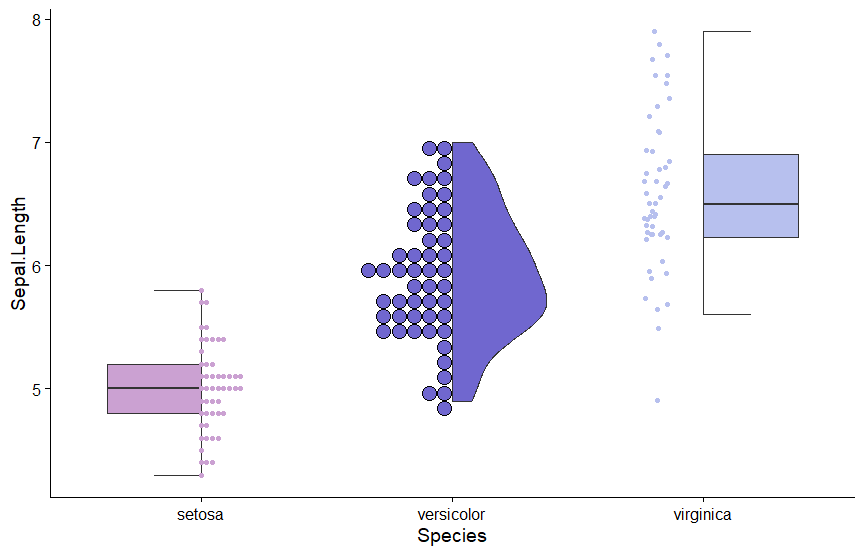

```r
ggplot() +

  geom_half_boxplot(
    data = iris %>% filter(Species=="setosa"),
    aes(x = Species, y = Sepal.Length, fill = Species), outlier.color = NA) +

  ggbeeswarm::geom_beeswarm(
    data = iris %>% filter(Species=="setosa"),
    aes(x = Species, y = Sepal.Length, fill = Species, color = Species), beeswarmArgs=list(side=+1)
  ) +

  geom_half_violin(
    data = iris %>% filter(Species=="versicolor"),
    aes(x = Species, y = Sepal.Length, fill = Species), side="r") +

  geom_half_dotplot(
    data = iris %>% filter(Species=="versicolor"),
    aes(x = Species, y = Sepal.Length, fill = Species), method="histodot", stackdir="down") +

  geom_half_boxplot(
    data = iris %>% filter(Species=="virginica"),
    aes(x = Species, y = Sepal.Length, fill = Species), side = "r", errorbar.draw = TRUE,
    outlier.color = NA) +

  geom_half_point(
    data = iris %>% filter(Species=="virginica"),
    aes(x = Species, y = Sepal.Length, fill = Species, color = Species), side = "l") +

  scale_fill_manual(values = c("setosa" = "#cba1d2", "versicolor"="#7067CF","virginica"="#B7C0EE")) +
  scale_color_manual(values = c("setosa" = "#cba1d2", "versicolor"="#7067CF","virginica"="#B7C0EE")) +
  theme(legend.position = "none")
```